# Models in Ecology

Lab 3

Maria Kuruvilla, Mark Lewis

Oct 2025

## 1 Modelling background and equations

In this lab we use mixed effects models, containing both fixed and random effects, to assess the impacts of sea lice on salmon returns. The approach we will take follows the class reading of Krkošek and Hilborn (2011). However, there are some differences. We will have an updated data set, which include later years with lower sea lice levels. Also, so as to keep things manageable we will only fit a subset of the models given in Krkošek and Hilborn (2011).

We will draw on the theory of Lecture 10 of the BIOL 470/550B class (Mixed Effects Models). Please review these notes. Pay particular attention to the pages on “Which random effects should we include?”, “Testing random effects structure” and “Crossed vs. nested random effects”. They will all be helpful here.

Please also have the Krkošek and Hilborn (2011) handy as we will be referring to it throughout the lab. Finally, it is easier to read the equations in this lab if you download the file to your computer and read it using Word.

## 2 Background: Fitting mixed-effects models in R

We will use the R package lme4 to fit linear mixed-effects models. You may need to install and load this package if you haven’t already.

```r
install.packages("lme4")
library(lme4)
```

It is also good to install this package

```r
install.packages("Rcpp")
library(Rcpp)
```

and one for plotting

```r
install.packages("gplots")
library(gplots)
```

If you haven’t installed the packages from the prerequisites document, install them now. If you have installed them, you might need to load them again.

```r
list.of.packages <- c("ggplot2", "tidyverse", "here", "tidybayes")

new.packages <- list.of.packages[!(list.of.packages %in% installed.packages()[,"Package"])]

if(length(new.packages)) install.packages(new.packages)

#load packages
library(rstan)
rstan_options("auto_write" = TRUE)
options(mc.cores = parallel::detectCores())
library(tidybayes)
library(here)
library(tidyverse)
library(ggplot2)
```

Assuming that you are starting from a fresh RStudio session you can select “no” to restarting R and you can also select “no” to compiling the source code from scratch when prompted by R.

The function lmer is much the same as the function lm that we used in Lab 2, but gives us the option to include random effects. When fitting a model using lmer, the fixed effects are specified as in lm, and the random effects are included in parentheses (Table 1). For example, a model fit to response data y, with covariate x in which we want to account for a random effect of group, b, on the intercept would be coded as:

```r
lmer(y~x+(1|b))
```

There are many online resources for fitting mixed effects models in R, so if you have a question, do a quick Google search. Someone else probably had that question too. And of course, you can always ask me. Here are some ways to specify random effects in lmer for grouping factors b and c with covariate x.

| Code | Random effect on: |
| --- | --- |
| (1\|b) | Intercept |
| (0+x\|b) | Slope |
| (1+x\|b) | Intercept & Slope |
| (x\|b) | Intercept & Slope |
| (1\|b) + (1\|c) | Crossed random effects on intercept |
| (1\|b/c) | Nested random effects on intercept |

## 3 Mixed-effects models for salmon populations

Read Krkosek and Hilborn (2011) (henceforth referred to as KH), focusing on the section Stock recruit model, in which they develop a hierarchical version of the Ricker model that includes random effects to account for spatial and temporal co-variation among populations. The full model they present (equation 7) for the log ratio of recruits to spawners is:

$$ln(R_{i,t}/N_{i,t-2}) = (r_{j} +
\theta_{i} + \theta_t + \theta_{t,area}) - b_{i} N_{i,t-2} +
\epsilon_{i,t}$$

Here

- the index $i$ indicates which of the up to 128 pink salmon populations (64 Rivers x 2 options for Odd_Even years) is being considered,
- the index $j$ enumerates the exposure category (in KH there are 6 and in our data set there are 8),
- the index $t$ gives the return year (Return_Yr) and
- the index $a$ describes which of the fisheries management areas (Area) the population is found in.

Note that equation (1) indicates that the population dynamics are analyzed at the level of the individual populations: the index i appears in each of the variables. Equation (1) indicates that the analysis will occur at the level of each population. The spawners and recruits are measured for each population: the index I appears in the formulas. The density dependence b_i will also be different for each population, as will the noise term $\epsilon_{i,t}$. What we are really interested in from an ecological perspective is how the growth rate $r$ is structured across exposure categories, indexed by $j$, (rather than across populations, indexed by $i$). However, to deal with the hierarchy of different factors effecting the growth rate, random effects at the levels of return years (indexed by $t$), populations (indexed by $i$) and management areas (indexed by $a$) are also included in the growth rate analysis.

The six exposure classes in KH were given by 3 time periods relative to when infestations occurred (before, during, fallow) x two exposure to sea lice options (exposed and unexposed to sea lice from farmed salmon). Here exposure to the sea lice came from populations being in management area 12 where the fish farms were present.

However, the data we will use for this lab come from a newer dataset that includes return years to 2009. Therefore, we will include a fourth time period, “after” infestations (see Peacock et al. (2013) for more on this, where it is shown that changes in farm management greatly reduced the impact of sea lice in later years). Thus, the eight exposure classes we have are unexposed-before, unexposed-fallow, unexposed-during, unexposed-after, exposed-before, exposed-fallow, exposed-during, exposed-after. Of these 8 classes, only one of them (exposed-during) give both the location and time interval where the wild salmon returns were hypothesized by KH to be influenced by the sea lice on salmon farms that juveniles were exposed to on their out-migration to the ocean. Download the spawner-recruit “Pink S-R data” as a .csv file. Read those data into R.

```r
data <- read.csv(here("lab3","Pink_S-R_data.csv"))

# get a glimpse of the data
glimpse(data)
```

```
## Rows: 1,762
## Columns: 6
## $ Return_Yr <int> 1972, 1978, 1980, 1982, 1984, 1986, 1988, 1990, 1992, 1972, …
## $ Odd_Even  <int> 2, 2, 2, 2, 2, 2, 2, 2, 2, 2, 2, 2, 2, 2, 2, 2, 2, 2, 2, 2, …
## $ River     <chr> "Pine", "Pine", "Pine", "Pine", "Pine", "Pine", "Pine", "Pin…
## $ Area      <int> 7, 7, 7, 7, 7, 7, 7, 7, 7, 7, 7, 7, 7, 7, 7, 7, 7, 7, 7, 7, …
## $ Spawners  <int> 9000, 4500, 1000, 600, 2000, 700, 550, 25, 130, 12000, 5000,…
## $ Recruits  <int> 5891, 2143, 1702, 4014, 1200, 2661, 61, 260, 306, 29457, 853…
```

The Return_Yr is the year that the Recruits came back to spawn, meaning that the Spawners column refers to the spawners that started in year Return_Yr-2. Area refers to the Department of Fisheries and Oceans statistical management area, which is the spatial scale at which catch data are reported (see http://www.pac.dfo-mpo.gc.ca/fm-gp/maps-cartes/areas-secteurs/index-eng.html). Note that because odd and even year returns do not mix and are treated as separate populations, a population is given by a combination of River and Odd_Even. Create a column for population (by combining river and Odd_Even). Then calculate survival as log(Recruits/Spawners). Create a column for exposure category (by combining exposure and time_period). Finally, create a column for time series length, start row and end row for each population. We will need this to differentiate the data from different populations in stan.

Now use the unique and the length functions in R to check how many return years, management areas and populations there are in the data frame.

```r
data_new <- data %>%
  mutate(survival = log(Recruits/Spawners),
         population = paste(River,Odd_Even),
         time_period = case_when(Return_Yr < 2002 ~ factor("before"),
                                 Return_Yr == 2004 ~ factor("fallow"),
                                 Return_Yr >= 2002 & Return_Yr <= 2006 ~ factor("during"),
                                 Return_Yr > 2006 ~ factor("after")),
         exposure = as.factor(ifelse(Area==12, "exposed","unexposed"))) %>%
  mutate(exposure_category = paste(exposure, time_period),
         row_number = row_number()) %>%
  # add a column with the start row number and another with the end row number for
  # the time series of each population
  group_by(population) %>%
  mutate(time_series_length = n(),
         start_row = first(row_number),
         end_row = last(row_number)) %>%
  ungroup()



glimpse(data_new)
```

```
## Rows: 1,762
## Columns: 15
## $ Return_Yr          <int> 1972, 1978, 1980, 1982, 1984, 1986, 1988, 1990, 199…
## $ Odd_Even           <int> 2, 2, 2, 2, 2, 2, 2, 2, 2, 2, 2, 2, 2, 2, 2, 2, 2, …
## $ River              <chr> "Pine", "Pine", "Pine", "Pine", "Pine", "Pine", "Pi…
## $ Area               <int> 7, 7, 7, 7, 7, 7, 7, 7, 7, 7, 7, 7, 7, 7, 7, 7, 7, …
## $ Spawners           <int> 9000, 4500, 1000, 600, 2000, 700, 550, 25, 130, 120…
## $ Recruits           <int> 5891, 2143, 1702, 4014, 1200, 2661, 61, 260, 306, 2…
## $ survival           <dbl> -0.423798815, -0.741870680, 0.531804030, 1.90061387…
## $ population         <chr> "Pine 2", "Pine 2", "Pine 2", "Pine 2", "Pine 2", "…
## $ time_period        <fct> before, before, before, before, before, before, bef…
## $ exposure           <fct> unexposed, unexposed, unexposed, unexposed, unexpos…
## $ exposure_category  <chr> "unexposed before", "unexposed before", "unexposed …
## $ row_number         <int> 1, 2, 3, 4, 5, 6, 7, 8, 9, 10, 11, 12, 13, 14, 15, …
## $ time_series_length <int> 9, 9, 9, 9, 9, 9, 9, 9, 9, 16, 16, 16, 16, 16, 16, …
## $ start_row          <int> 1, 1, 1, 1, 1, 1, 1, 1, 1, 10, 10, 10, 10, 10, 10, …
## $ end_row            <int> 9, 9, 9, 9, 9, 9, 9, 9, 9, 25, 25, 25, 25, 25, 25, …
```

Now you should have all the data you need to fit the models described in KH on page 21: all possible combinations of random effects, each with and without the growth rate structured by exposure category. However, in this lab we focus on four categories of the random effects models in KH, which we call models 1 (no random effects), 3 (random effect for intercept on Return_Yr), 4 (random effect for intercept on Area), and 7 (random effect for intercept on Area nested within Return_Yr). These are given in rows 1, 3, 4, and 7 of KH Table 2. For each of these models we are interested in the effect of the exposure category on the population growth rate. Thus, we fit each of the models with no exposure categories (model a) and with the 8 exposure categories given above (model b). Note that the population growth rate alpha is the intercept term in equation (1).

You can visualize the data using the following code. Since there are many populations, we can group the plots by area.

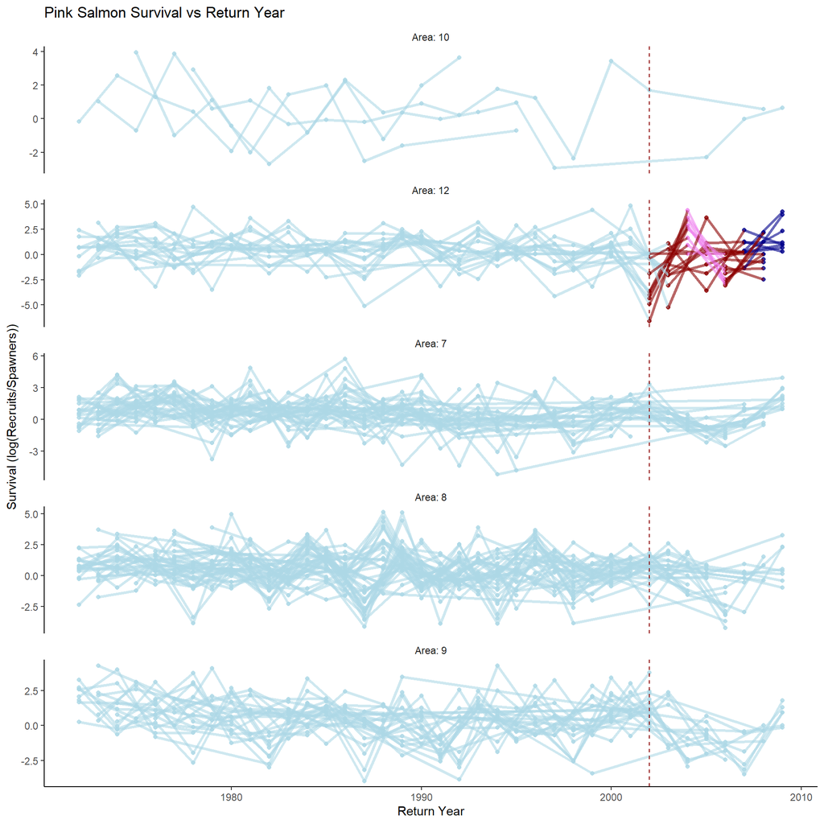

```r
ggplot(data_new, aes(x = Return_Yr, y = survival, group = population))+
  geom_point(alpha = 0.8, aes(color = exposure_category))+
  geom_line(aes(color = exposure_category), alpha = 0.6, size = 1.2)+
  geom_vline(xintercept = 2002, linetype = "dashed", color = "darkred")+
  facet_wrap(~paste("Area:",Area), ncol = 1, scales = "free_y") +
  scale_color_manual(values = c("exposed before" = "lightblue",
                                "exposed during" = "darkred",
                              "exposed after" = "darkblue",
                              "exposed fallow" = "violet",
                              "unexposed before" = "lightblue",
                              "unexposed during" = "lightblue",
                              "unexposed after" = "lightblue",
                              "unexposed fallow" = "lightblue")) +
  theme_classic()+
  theme(strip.background = element_blank(),
        legend.position = "none") +
  labs(title = "Pink Salmon Survival vs Return Year",
       x = "Return Year",
       y = "Survival (log(Recruits/Spawners))",
       color = "Exposure Category")
```

In summary we will have models

- 1a: no random effect, no exposure categories,
- 1b: no random effects, exposure categories,
- 3a: random effect for intercept on Return_Yr, no exposure categories,
- 3b random effect for intercept on Return_Yr, exposure categories,
- 4a random effect for intercept on Area, no exposure categories,
- 4b: random effect for intercept on Area, exposure categories,
- 7a: random effect for intercept on Area nested within Return_Yr, no exposure categories, and
- 7b: random effect for intercept on Area nested within Return_Yr, exposure categories.

Our goal in this lab is create a table with columns as given in Table 2 of KH, but with eight rows, describing the eight models given above. Return to Table 1 and determine how to write the random effects in the last six models above using R.  
Recall from our earlier discussion that each the models are run for each of the populations (indexed by i) in equation (1). To start we consider the case with no random effects. In this case the R function lm suffices to fit the model.

```r
fit1a <- lm(Survival~Population:Spawners,data=data)
```

Why do we use Population:Spawners in the above command? Try looking at the results from the analyses using

```r
summary(fit1a)
```

Note that the intercept is given. This is the estimate for the growth rate. Note also that the slope of the line b_i is also given for each of the populations. Now include the exposure category

```r
fit1b <- lm(Survival~0+exposure_category+Population:Spawners, data=data)
```

Again, try looking at the results from the analyses, from fit1b. We can plot these results with a bar chart:

```r
bp1<-barplot2(summary(fit1b)$coefficients[1:8,1], plot.ci=TRUE, ci.l=summary(fit1b)$coefficients[1:8,1]-1.96*summary(fit1b)$coefficients[1:8,2], ci.u=summary(fit1b)$coefficients[1:8,1]+1.96*summary(fit1b)$coefficients[1:8,2], col=grey(c(0.4, 0.8)), names.arg=FALSE,ylab="Population growth rate")
```

and then add labels

```r
for(i in 1:4) text(mean(bp1[(2*i-1):(2*i)]), -0.5, levels(data$time_period)[i], xpd=TRUE)
```

as well as a legend:

```r
legend("topright", fill=grey(c(0.4, 0.8)), c("Exposed", "Unexposed"), bty="n")
```

What kind of error bars have been added to these plots? The log likelihoods and AICs of each of the fits can be calculated using:

```r
lL1a <- logLik(fit1a)
lL1b <- logLik(fit1b)
AIC1a <- AIC(fit1a)
AIC1b <- AIC(fit1b)
```

Check the values for these quantities. Note that model 1a is nested within model 1b. This allows for the use of the likelihood ratio test (LRT) to see if there is sufficient evidence to reject the null hypothesis that exposure category does not alter the growth rate significantly. Here the test statistic

```r
teststat1 <- -2 * (as.numeric(lL1a)-as.numeric(lL1b))
```

has an asymptotically Chi-Squared distribution with the degrees of freedom equal to the difference in the number of degrees of freedom of the more complicated model (fit1b). minus the degrees of freedom from the simpler model (fit1a). Work out the number of degrees of freedom for each (hint: use the summary function) and use the pchisq function to evaluate whether the null hypothesis can be rejected.

```r
p.val1 <- pchisq(teststat1, df = …, lower.tail = false)
```

When lower.tail = false in the pchisq function we are asking for the probability the value teststat1 or larger could have been observed from the Chi-Squared distribution with the appropriate degrees of freedom and this is what we want for a p value. Record the p value. Are we able to reject the null hypothesis?

```r
fit7a <- lmer(Survival~Population:Spawners+(1|Return_Yr/Area), REML=TRUE, data=data)
fit7b <- lmer(Survival~0+exposure_category+Population:Spawners+(1|Return_Yr/Area), REML=TRUE, data=data)
AIC7a  <-  AIC(fit7a)
AIC7b  <- AIC(fit7b)
```

```r
fit7a_fixed<-lmer(Survival~Population:Spawners+(1|Return_Yr/Area), REML=FALSE, data=data)
fit7b_fixed<-lmer(Survival~0+exposure_category+Population:Spawners+(1|Return_Yr/Area), REML=FALSE, data=data)
AIC7a  <-  AIC(fit7a_fixed)
AIC7b  <- AIC(fit7b_fixed)
ll7a_fixed<-logLik(fit7a_fixed)
ll7b_fixed<-logLik(fit7b_fixed)
teststat7_fixed <- -2 * (as.numeric(ll7a_fixed)-as.numeric(ll7b_fixed))
```

Work out the number of degrees of freedom and use the pchisq function to evaluate whether the null hypothesis can be rejected. Record the p value. Then repeat this procedure for models 3 and 4.

```r
p.val7 <- pchisq(…, df = …, lower.tail = false)
```

(You fill in the …). Finally, create a Table with columns the same as Table 2 in KH and rows that are suitable for models 1, 3, 4 and 7 and populate the table with what you have found. You are now ready to move on to Assignment 3!

## 4 Literature Cited

Krkošek, M. & Hilborn, R., 2011. Sea lice (Lepeophtheirus salmonis) infestations and the productivity of pink salmon (Oncorhynchus gorbuscha) in the Broughton Archipelago, British Columbia, Canada. Canadian Journal of Fisheries and Aquatic Sciences, 68(1), pp.17–29. Available at: http://www.nrcresearchpress.com/doi/abs/10.1139/F10-137.

Peacock, S.J. et al., 2013. Cessation of a salmon decline with control of parasites. Ecological Applications, 23(3), pp.606–620. Available at: http://www.esajournals.org/doi/abs/10.1890/12-0519.1.